# Analysis of Suicide Rates in the United States

Collaborators: Iman Tura, Saurav Vidyadhara

**Disclaimer:** This project contains heavy themes discussing mental health and suicidal ideation. If you or a loved one is dealing with one of these issues, we implore you to utilize this list of resources compiled below.

List of resources:  
1. Suicide and Crisis Lifeline: 988  
2. UMD resources for mental health: https://psyc.umd.edu/sites/psyc.umd.edu/files/UMD%20Campus%20Resources.pdf  
3. SAMHSA’s National Helpline: 1-800-662-4357 (HELP)  
4. Find treatment by location: https://findtreatment.gov/locator

## Introduction

Suicide has emerged as one of the most significant yet untreated public health threats within the United States. According to the American Foundation for Suicide Prevention, suicide is listed as the 11th leading cause for death in the United States, causing a reported 49,476 deaths in 2022, and nearly two million deaths<sup>1</sup>. This alarming rate underscores the importance of addressing mental health issues and understanding the factors that contribute to suicide risk which will be the focus of this analysis. In investigation for this project we found various protective key factors that may contribute to a person’s risk for suicidal ideation. For example, according to a study performed by the National Journal of Medicine, "Rates of suicide increase during the life course and are highest among middle- to old-age adults"<sup>2</sup>. Additionally, a cross-national comparison of suicide rates found that "historically, male suicide rates are higher than female"<sup>3</sup>. From this research we have decided to focus on identifying and analyzing the demographic variables (age, race, gender, etc.) that contribute to these trends.

```
The following analysis examines the relationship between identity (age, race, gender, and ethnicity) and suicide rates in the United States, aiming to identify critical factors that contribute to increased risk among various demographic groups.
```

The purpose of the following project is to follow the data science lifecycle, explored within the classroom setting, leveraging data science techniques to unearth invaluable insight as to the state of American public health. Why might this be important? It is our belief that a study of protective key factors that may contribute to increase risk of suicide can not only identify vulnerable demographics, but also target these groups in order to create sustainable solutions that may address the United States public health crisis.

```
This analysis will follow the entire data science pipeline: data curation, parsing, and management within the following five parts of the analysis:
    1. Data Collection
    2. Data Processing
    3. Exploratory Analysis and Data Visualization
    4. Hypothesis Testing, Model Analysis, and Machine Learning
    5. Interpolation: Insight and Policy Decision
```

## Part 1: Data Collection

The data science conducted within this project was developed in tandem with Python and Jupiter Notebook. Further reading on this topic can be found at the bottom of this page<sup>4</sup>.

**Python imports for the entire project can be found here and are organized by purpose in project and module:**

```python
#Python libraries for obtaining data through JSON requests
import json
import requests

#Python libraries for creating and manipulating data frame
import pandas as pd

#Python libraries for data visualization
import matplotlib.pyplot as plt

#Python libraries for Hypothesis Testing, Model Analysis, and Machine Learning
import seaborn as sns
import numpy as np
import statsmodels.formula.api as smf
from sklearn.model_selection import train_test_split
from sklearn.neighbors import KNeighborsClassifier
from sklearn.metrics import classification_report, confusion_matrix
```

The data we have chosen for this project can be accessed at the website for The Home of the U.S. Government's Open Data, and can be accessed via this link: https://catalog.data.gov/dataset/death-rates-for-suicide-by-sex-race-hispanic-origin-and-age-united-states-020c1. This data follows the "death rates for suicide, by selected population characteristics"<sup>5</sup> and is a study conducted by the Centers for Disease Control and Prevention's National Center for Health Statistics.

Utilizing a JSON get request we access the data of death rates for suicide, by sex, race, Hispanic origin, and age: United States between the selected years 1950–2018.

```python
# URL of the JSON data
url = 'https://data.cdc.gov/api/views/9j2v-jamp/rows.json?accessType=DOWNLOAD'

# Fetch the JSON content from the URL
response = requests.get(url)
json_content = response.text

# Parse JSON content
data = json.loads(json_content)
```

## Part 2: Data Processing

In the following code, after extracting the data from the JSON file and placing this data in a pandas dataframe (done above), extract columns and place them with their respective roles. The table seen below is the raw data, as presented by the JSON, before any true data processing and cleaning.

```python
# Extract 'columns' data
columns_data = data['data']
df = pd.DataFrame(columns_data)
# Convert to DataFrame
df = pd.DataFrame(columns_data)
df.columns = ['sid', 'id', 'position', 'created_at', 'created_meta', 'updated_at', 'updated_meta', 'meta',
              'INDICATOR', 'UNIT', 'UNIT_NUM', 'STUB_NAME', 'STUB_NAME_NUM', 'STUB_LABEL', 'STUB_LABEL_NUM',
              'YEAR', 'YEAR_NUM', 'AGE', 'AGE_NUM', 'ESTIMATE', 'FLAG']


# Display the DataFrame
df
```

|  | sid | id | position | created_at | created_meta | updated_at | updated_meta | meta | INDICATOR | UNIT | ... | STUB_NAME | STUB_NAME_NUM | STUB_LABEL | STUB_LABEL_NUM | YEAR | YEAR_NUM | AGE | AGE_NUM | ESTIMATE | FLAG |
| --- | --- | --- | --- | --- | --- | --- | --- | --- | --- | --- | --- | --- | --- | --- | --- | --- | --- | --- | --- | --- | --- |
| 0 | row-sj5k-g243-v6cb | 00000000-0000-0000-ED82-9AA08DFD0A9A | 0 | 1623083971 | None | 1623083971 | None | { } | Death rates for suicide | Deaths per 100,000 resident population, age-ad... | ... | Total | 0 | All persons | 0 | 1950 | 1 | All ages | 0 | 13.2 | None |
| 1 | row-ejmi~wx6s-9cxn | 00000000-0000-0000-6815-4FD0CEFCA3F6 | 0 | 1623083971 | None | 1623083971 | None | { } | Death rates for suicide | Deaths per 100,000 resident population, age-ad... | ... | Total | 0 | All persons | 0 | 1960 | 2 | All ages | 0 | 12.5 | None |
| 2 | row-db2i-62a7_cm7e | 00000000-0000-0000-3CBC-D99BAFDC625B | 0 | 1623083971 | None | 1623083971 | None | { } | Death rates for suicide | Deaths per 100,000 resident population, age-ad... | ... | Total | 0 | All persons | 0 | 1970 | 3 | All ages | 0 | 13.1 | None |
| 3 | row-usyq~7vsy~ag46 | 00000000-0000-0000-DAE8-3BAD17B11C1C | 0 | 1623083971 | None | 1623083971 | None | { } | Death rates for suicide | Deaths per 100,000 resident population, age-ad... | ... | Total | 0 | All persons | 0 | 1980 | 4 | All ages | 0 | 12.2 | None |
| 4 | row-susv_w5b7_mr7x | 00000000-0000-0000-4D4D-902B4D920BE3 | 0 | 1623083971 | None | 1623083971 | None | { } | Death rates for suicide | Deaths per 100,000 resident population, age-ad... | ... | Total | 0 | All persons | 0 | 1981 | 5 | All ages | 0 | 12.3 | None |
| ... | ... | ... | ... | ... | ... | ... | ... | ... | ... | ... | ... | ... | ... | ... | ... | ... | ... | ... | ... | ... | ... |
| 6385 | row-3868~iife.snwt | 00000000-0000-0000-8180-6FC9C0A4BBDD | 0 | 1623083971 | None | 1623083971 | None | { } | Death rates for suicide | Deaths per 100,000 resident population, crude | ... | Sex, age and race and Hispanic origin (Single ... | 11 | Female: Not Hispanic or Latino: Black or Afric... | 7.225 | 2018 | 42 | 65 years and over | 5 | 1.3 | None |
| 6386 | row-rqgk_q3qw_grn6 | 00000000-0000-0000-5BA7-DC975537C46A | 0 | 1623083971 | None | 1623083971 | None | { } | Death rates for suicide | Deaths per 100,000 resident population, crude | ... | Sex, age and race and Hispanic origin (Single ... | 11 | Female: Hispanic or Latino: All races: 15-24 y... | 7.232 | 2018 | 42 | 15-24 years | 2 | 4.1 | None |
| 6387 | row-yp49~mju7-9dka | 00000000-0000-0000-6013-6AD3ED22FF09 | 0 | 1623083971 | None | 1623083971 | None | { } | Death rates for suicide | Deaths per 100,000 resident population, crude | ... | Sex, age and race and Hispanic origin (Single ... | 11 | Female: Hispanic or Latino: All races: 25-44 y... | 7.233 | 2018 | 42 | 25-44 years | 3 | 4.4 | None |
| 6388 | row-yrr2_89hh.am8m | 00000000-0000-0000-383B-FA52D078E4A7 | 0 | 1623083971 | None | 1623083971 | None | { } | Death rates for suicide | Deaths per 100,000 resident population, crude | ... | Sex, age and race and Hispanic origin (Single ... | 11 | Female: Hispanic or Latino: All races: 45-64 y... | 7.234 | 2018 | 42 | 45-64 years | 4 | 3.2 | None |
| 6389 | row-85u2_2w2j-54ts | 00000000-0000-0000-DF29-2F4A1828270A | 0 | 1623083971 | None | 1623083971 | None | { } | Death rates for suicide | Deaths per 100,000 resident population, crude | ... | Sex, age and race and Hispanic origin (Single ... | 11 | Female: Hispanic or Latino: All races: 65 year... | 7.235 | 2018 | 42 | 65 years and over | 5 | 1.6 | None |

6390 rows × 21 columns

Now we begin the process of **data cleaning**. We begin by making the table more readable by standardizing labels assigned to various demographic attributes. For example in the column which ascribes ethnicity by stating if the dempgraphic is 'Hispanic or Latino' or 'Not Hispanic or Latino', we shortened this column to only have the observations yes, no, or unknown. A legend for these changes can be found below.

```python
#Making gender more readable
df['GENDER'] = df['STUB_LABEL'].apply(lambda x: 'male' if 'Male' in x else 'female' if 'Female' in x else 'both')
#Making ethnicity more readable
df['IS_HISPANIC'] = df['STUB_LABEL'].apply(lambda x: 'no' if 'Not Hispanic or Latino' in x else 'yes' if
                                           'Hispanic or Latino' in x else 'unknown')
#Making race more readable
df['RACE'] = df['STUB_LABEL'].apply(lambda x: 'white' if 'White' in x else 'black' if
                                    'Black or African American' in x else 'indigenous' if
                                    'American Indian or Alaska Native' in x else 'aapi' if
                                    'Asian or Pacific Islander' in x else 'all')
# Display the DataFrame
df
```

|  | sid | id | position | created_at | created_meta | updated_at | updated_meta | meta | INDICATOR | UNIT | ... | STUB_LABEL_NUM | YEAR | YEAR_NUM | AGE | AGE_NUM | ESTIMATE | FLAG | GENDER | IS_HISPANIC | RACE |
| --- | --- | --- | --- | --- | --- | --- | --- | --- | --- | --- | --- | --- | --- | --- | --- | --- | --- | --- | --- | --- | --- |
| 0 | row-sj5k-g243-v6cb | 00000000-0000-0000-ED82-9AA08DFD0A9A | 0 | 1623083971 | None | 1623083971 | None | { } | Death rates for suicide | Deaths per 100,000 resident population, age-ad... | ... | 0 | 1950 | 1 | All ages | 0 | 13.2 | None | both | unknown | all |
| 1 | row-ejmi~wx6s-9cxn | 00000000-0000-0000-6815-4FD0CEFCA3F6 | 0 | 1623083971 | None | 1623083971 | None | { } | Death rates for suicide | Deaths per 100,000 resident population, age-ad... | ... | 0 | 1960 | 2 | All ages | 0 | 12.5 | None | both | unknown | all |
| 2 | row-db2i-62a7_cm7e | 00000000-0000-0000-3CBC-D99BAFDC625B | 0 | 1623083971 | None | 1623083971 | None | { } | Death rates for suicide | Deaths per 100,000 resident population, age-ad... | ... | 0 | 1970 | 3 | All ages | 0 | 13.1 | None | both | unknown | all |
| 3 | row-usyq~7vsy~ag46 | 00000000-0000-0000-DAE8-3BAD17B11C1C | 0 | 1623083971 | None | 1623083971 | None | { } | Death rates for suicide | Deaths per 100,000 resident population, age-ad... | ... | 0 | 1980 | 4 | All ages | 0 | 12.2 | None | both | unknown | all |
| 4 | row-susv_w5b7_mr7x | 00000000-0000-0000-4D4D-902B4D920BE3 | 0 | 1623083971 | None | 1623083971 | None | { } | Death rates for suicide | Deaths per 100,000 resident population, age-ad... | ... | 0 | 1981 | 5 | All ages | 0 | 12.3 | None | both | unknown | all |
| ... | ... | ... | ... | ... | ... | ... | ... | ... | ... | ... | ... | ... | ... | ... | ... | ... | ... | ... | ... | ... | ... |
| 6385 | row-3868~iife.snwt | 00000000-0000-0000-8180-6FC9C0A4BBDD | 0 | 1623083971 | None | 1623083971 | None | { } | Death rates for suicide | Deaths per 100,000 resident population, crude | ... | 7.225 | 2018 | 42 | 65 years and over | 5 | 1.3 | None | female | no | black |
| 6386 | row-rqgk_q3qw_grn6 | 00000000-0000-0000-5BA7-DC975537C46A | 0 | 1623083971 | None | 1623083971 | None | { } | Death rates for suicide | Deaths per 100,000 resident population, crude | ... | 7.232 | 2018 | 42 | 15-24 years | 2 | 4.1 | None | female | yes | all |
| 6387 | row-yp49~mju7-9dka | 00000000-0000-0000-6013-6AD3ED22FF09 | 0 | 1623083971 | None | 1623083971 | None | { } | Death rates for suicide | Deaths per 100,000 resident population, crude | ... | 7.233 | 2018 | 42 | 25-44 years | 3 | 4.4 | None | female | yes | all |
| 6388 | row-yrr2_89hh.am8m | 00000000-0000-0000-383B-FA52D078E4A7 | 0 | 1623083971 | None | 1623083971 | None | { } | Death rates for suicide | Deaths per 100,000 resident population, crude | ... | 7.234 | 2018 | 42 | 45-64 years | 4 | 3.2 | None | female | yes | all |
| 6389 | row-85u2_2w2j-54ts | 00000000-0000-0000-DF29-2F4A1828270A | 0 | 1623083971 | None | 1623083971 | None | { } | Death rates for suicide | Deaths per 100,000 resident population, crude | ... | 7.235 | 2018 | 42 | 65 years and over | 5 | 1.6 | None | female | yes | all |

6390 rows × 24 columns

### **Legend Names Changed:**

**GENDER**  
male = Male  
female = Female  
both = group is both male and female  
**Ethnicity**  
yes = Hispanic or Latino  
no = Not Hispanic or Latino  
Unknown = Group is unknown (both hispanic and not)  
**RACE**  
Black = Black or African American  
White = White  
Indigenous = American Indian or Alaskan Native  
AAPI = Asian American or Pacific Islander  
All = Group is comprised of all races

#### **Caveat in data:**

It is important to acknowledge that our data follows the number of suicides that occur within each population within the United States per 100,000 resident population (eg. the number of suicides that occur within the population of black women), these number are not impacted by the portion of the population each group falls under. According to the United States Census, the population of White Men within the US is much larger than the population of Black Women. Thus it is natural to assume that the number of suicides within the population of White men is larger than the number of suicides that occur within the population of Black Women. However, this misconception would be incorrect as the data indicates suicide rates per 100,000 individuals, providing a more accurate measure of risk across different demographic groups.

To explore these numbers fully we created two additional columns. Group_pop is a column that demonstrates the population in millions of every race listed in the legend above during their respective timeframes accoridng to the United States Census Bureau<sup>6</sup>. While this data is not utilized in our analysis it helps analyze the trend of growth or depression in certain populations. Percent is a column that uses the estimated number of suicides per 100,000 within a demographic (column: estimates) and divides it by 100,000 to create an estimates suicide rate per each population. These numbers are represented by the following rate of suicide equation found below.

$$ \text{Rate of Suicide (Percent)} = \frac{\text{Number of Suicides per Group}}{\text{100,000}} $$

```python
# Population data according to the census (https://www.census.gov/)
population_data = [
    [1950, 134.9, 15.0, 0.5, 0.3],
    [1960, 158.8, 18.9, 0.9, 0.5],
    [1970, 178.1, 22.6, 1.5, 0.8],
    [1980, 188.4, 26.5, 3.5, 1.4],
    [1990, 199.7, 30.0, 6.9, 2.0],
    [2000, 211.5, 34.7, 10.2, 2.5],
    [2010, 223.6, 38.9, 14.7, 3.0]
]

#assign group population accroding to census
def assign_population(row):
    i, j = 0, 0
    if int(row['YEAR']) // 10 == 195:
        i = 0
    elif int(row['YEAR']) // 10 == 196:
        i = 1
    elif int(row['YEAR']) // 10 == 197:
        i = 2
    elif int(row['YEAR']) // 10 == 198:
        i = 3
    elif int(row['YEAR']) // 10 == 199:
        i = 4
    elif int(row['YEAR']) // 10 == 200:
        i = 5
    elif int(row['YEAR']) // 10 == 201:
        i = 6

    if row['RACE'] == 'white':
        j = 1
    elif row['RACE'] == 'black':
        j = 2
    elif row['RACE'] == 'indigenous':
        j = 3
    elif row['RACE'] == 'aapi':
        j = 4
    else:
        return population_data[i][1] + population_data[i][2] + population_data[i][3] + population_data[i][4]
    return population_data[i][j]
```

Here we are dropping unnesserary, superfluous columns to make the table more readable. This includes columns such as id, updated_at, or meta, all of which we will not use during our an anlysis. Next we rename the column names of the table to create a final cohesive table.

```python
df = df.drop(columns=['sid', 'id', 'position', 'created_at', 'created_meta', 'updated_at', 'updated_meta',
                      'meta', 'UNIT', 'UNIT_NUM', 'STUB_NAME', 'STUB_NAME_NUM', 'STUB_LABEL_NUM', 'YEAR_NUM',
                      'FLAG', 'INDICATOR', 'STUB_LABEL'])

df.rename(columns={'ESTIMATE': 'DEATH_PER_100k'}, inplace=True)
df['YEAR'] = df['YEAR'].astype(int)
df['AGE_NUM'] = df['AGE_NUM'].astype(float)
df['DEATH_PER_100k'] = df['DEATH_PER_100k'].astype(float)
df['GROUP_POP'] = df.apply(assign_population, axis=1)
df['PERCENT'] = df['DEATH_PER_100k'] / 100000
df
```

|  | YEAR | AGE | AGE_NUM | DEATH_PER_100k | GENDER | IS_HISPANIC | RACE | GROUP_POP | PERCENT |
| --- | --- | --- | --- | --- | --- | --- | --- | --- | --- |
| 0 | 1950 | All ages | 0.0 | 13.2 | both | unknown | all | 150.7 | 0.000132 |
| 1 | 1960 | All ages | 0.0 | 12.5 | both | unknown | all | 179.1 | 0.000125 |
| 2 | 1970 | All ages | 0.0 | 13.1 | both | unknown | all | 203.0 | 0.000131 |
| 3 | 1980 | All ages | 0.0 | 12.2 | both | unknown | all | 219.8 | 0.000122 |
| 4 | 1981 | All ages | 0.0 | 12.3 | both | unknown | all | 219.8 | 0.000123 |
| ... | ... | ... | ... | ... | ... | ... | ... | ... | ... |
| 6385 | 2018 | 65 years and over | 5.0 | 1.3 | female | no | black | 38.9 | 0.000013 |
| 6386 | 2018 | 15-24 years | 2.0 | 4.1 | female | yes | all | 280.2 | 0.000041 |
| 6387 | 2018 | 25-44 years | 3.0 | 4.4 | female | yes | all | 280.2 | 0.000044 |
| 6388 | 2018 | 45-64 years | 4.0 | 3.2 | female | yes | all | 280.2 | 0.000032 |
| 6389 | 2018 | 65 years and over | 5.0 | 1.6 | female | yes | all | 280.2 | 0.000016 |

6390 rows × 9 columns

### Missing data

Missing data may be Missing Completely at Random (MCAR), Missing at Random (MAR), or Missing Not at Random (MNAR). Missing data was not apart of our data frame as the way we input population paramerters into our charts. By carefully structuring our data inputs, we ensured that all necessary demographic information was included, thus issues related to incomplete data was avoided, enabling more accurate analysis and interpretation of the suicide rates across different population groups. For more information of missing data visit the works cited found below <sup>6</sup>.

## Part 3: Exploratory Analysis and Data Visualization

To analyze the distribution of suicide rates across our various factors contained within the table (age, gender, race, ethnicity). We have computed a number of statistical summaries and created a series of charts to explore the relationships between these demographic variables and suicide rates. This is done to convey lots of information with extreme simplicity and explore correlation.

#### **Caveats for graphs:**

**Correlation is not causation.** While, in this section, we demonstrate and analyze relationships that may or may not exist in the data (this will be the focus of section 4 of this project), we cannot say that any dependent variable (age, gender, race, ethnicity) is the cause of suicide rates. We use data visualization here to speculate on trends on to display data processed in the previous section of our code.

**Creation of our graphs.** We have relied on scatter plots for each factor (age, race, gender, ethnicity in the following code. This is developed in tandem with the plt library which makes it possible to map the relation between the era or year and number of suicided per 100,000 for each demographic.

### Suicide Trends in Various Age Groups

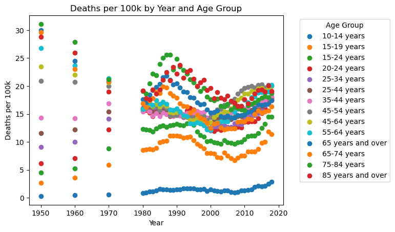

```python
age_filtered_df = df[(df['GENDER'] == 'both') &
                 (df['RACE'] == 'all') &
                 (df['IS_HISPANIC'] == 'unknown') &
                 (df['AGE'] != 'All ages')]

age_grouped_df = age_filtered_df.groupby(['YEAR', 'AGE'], as_index=False)['DEATH_PER_100k'].sum()

# Create the plot
fig, ax = plt.subplots()

# Plot each age group with a different marker
for age_num in age_grouped_df['AGE'].unique():
    age_group = age_grouped_df[age_grouped_df['AGE'] == age_num]
    ax.scatter(age_group['YEAR'], age_group['DEATH_PER_100k'], label=age_group['AGE'].iloc[0])

# Add labels and title
ax.set_xlabel('Year')
ax.set_ylabel('Deaths per 100k')
ax.set_title('Deaths per 100k by Year and Age Group')

# Position the legend on the right side of the plot
ax.legend(title='Age Group', bbox_to_anchor=(1.05, 1), loc='upper left')

# Show the plot
plt.show()
```

### Suicide Trends in Various Racial Groups

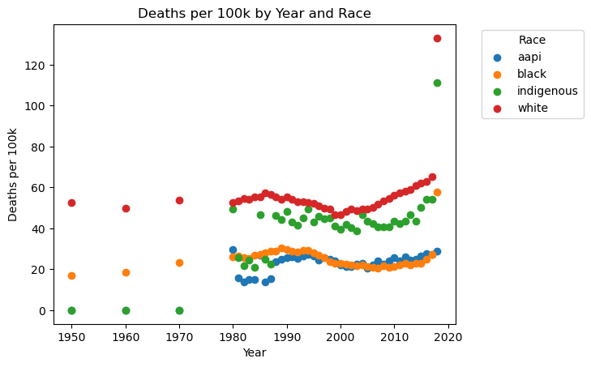

```python
race_filtered_df = df[(df['AGE'] == 'All ages') &
                      (df['IS_HISPANIC'] == 'unknown') &
                      (df['RACE'] != 'all')]

race_grouped_df = race_filtered_df.groupby(['YEAR', 'RACE'], as_index=False)['DEATH_PER_100k'].sum()

# Create the plot
fig, ax = plt.subplots()

# Plot each age group with a different marker
for age_num in race_grouped_df['RACE'].unique():
    age_group = race_grouped_df[race_grouped_df['RACE'] == age_num]
    ax.scatter(age_group['YEAR'], age_group['DEATH_PER_100k'], label=age_group['RACE'].iloc[0])

# Add labels and title
ax.set_xlabel('Year')
ax.set_ylabel('Deaths per 100k')
ax.set_title('Deaths per 100k by Year and Race')

# Position the legend on the right side of the plot
ax.legend(title='Race', bbox_to_anchor=(1.05, 1), loc='upper left')

# Show the plot
plt.show()
```

### Suicide Trends in Various Gender Groups

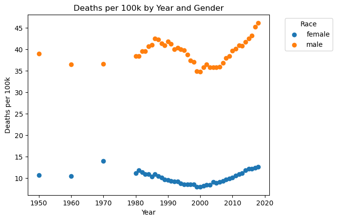

```python
filtered_df = df[(df['AGE'] == 'All ages') &
                 (df['AGE'] != '65 years and over') &
                 (df['IS_HISPANIC'] == 'unknown') &
                 (df['RACE'] == 'all') &
                 (df['GENDER'] != 'both')]

gender_grouped_df = filtered_df.groupby(['YEAR', 'GENDER'], as_index=False)['DEATH_PER_100k'].sum()

# Create the plot
fig, ax = plt.subplots()

# Plot each age group with a different marker
for age_num in gender_grouped_df['GENDER'].unique():
    age_group = gender_grouped_df[gender_grouped_df['GENDER'] == age_num]
    ax.scatter(age_group['YEAR'], age_group['DEATH_PER_100k'], label=age_group['GENDER'].iloc[0])

# Add labels and title
ax.set_xlabel('Year')
ax.set_ylabel('Deaths per 100k')
ax.set_title('Deaths per 100k by Year and Gender')

# Position the legend on the right side of the plot
ax.legend(title='Race', bbox_to_anchor=(1.05, 1), loc='upper left')

# Show the plot
plt.show()
```

Here we see a stark difference between men and women's rates of suicide, with it being around four times more likely than a man kills himself compared to a women. We see this echoed across many studies, including one by George Earl Murphy<sup>10</sup>, a famous psychiatrist who specialized in suicide prevention. He states that a strong reason for why women on average don't commit suicide is their interdependance.

### Suicide Trends in Various Ethnic Groups

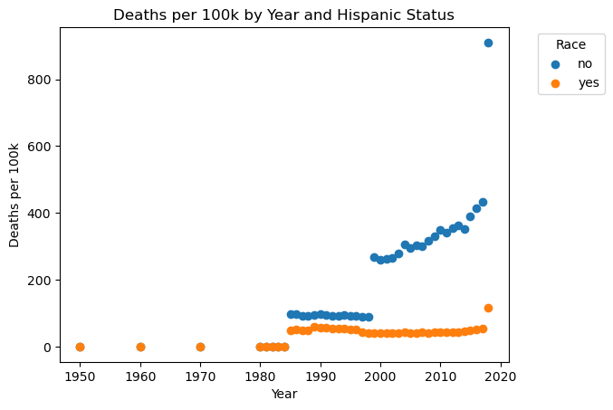

```python
hispanic_df = df[(df['AGE'] == 'All ages') &
                 (df['AGE'] != '65 years and over') &
                 (df['IS_HISPANIC'] != 'unknown') &
                 (df['GENDER'] != 'both')]
hispanic_df = df[(df['AGE'] != 'All ages') &
                 (df['AGE'] != '65 years and over') &
                 (df['IS_HISPANIC'] != 'unknown') &
                 (df['GENDER'] != 'both')]
hisp_grouped_df = hispanic_df.groupby(['YEAR', 'IS_HISPANIC'], as_index=False)['DEATH_PER_100k'].sum()

# Create the plot
fig, ax = plt.subplots()

# Plot each age group with a different marker
for age_num in hisp_grouped_df['IS_HISPANIC'].unique():
    age_group = hisp_grouped_df[hisp_grouped_df['IS_HISPANIC'] == age_num]
    ax.scatter(age_group['YEAR'], age_group['DEATH_PER_100k'], label=age_group['IS_HISPANIC'].iloc[0])

# Add labels and title
ax.set_xlabel('Year')
ax.set_ylabel('Deaths per 100k')
ax.set_title('Deaths per 100k by Year and Hispanic Status')

# Position the legend on the right side of the plot
ax.legend(title='Race', bbox_to_anchor=(1.05, 1), loc='upper left')

# Show the plot
plt.show()
```

This graph shows the differences between hispanic and latino suicide rates versus people who don't identify with that subgroup. The non Hispanic/Latino suicide rate is growing while the Hispanic/Latino one has been consistently lower over the period tracked. This stark difference can be attributed to, according to the NY Times<sup>11</sup>, by their close familial ties and social networks that help them build resiliance.

## Part 4: Hypothesis Testing, Model Analysis, and Machine Learning

## Hypothesis Testing and Model Analysis</h3>

"Hypothesis testing is a way of systematically quantifying how certain you are of the result of a statistical experiment"<sup>12</sup>. To conduct a hypothesis test you begin with the null hypothesis, the assupmtion that no realtionship occurs within this data. The alternate hypothesis represents the opposite. Then the data scientist conducts a model analysis to deduce if a relationship exists. For the pusposes of this project we rely on the ordinary least squares regression model in python provided by the statsmodels library. We then deduce whether we may reject or fail to reject the null hypothesis. In this section we complete a model for each factor (age, race, gender, and ethnicity) by year, before completing a final model where we test the effect of the independent variables age, race, gender, and ethnicity) on the suicide rate.

### Hypothesis Testing and Model Analysis of Age

**(H_0)**: No relationship exists between age and suicide rate.

```
                            OLS Regression Results
==============================================================================
Dep. Variable:         DEATH_PER_100k   R-squared:                       0.210
Model:                            OLS   Adj. R-squared:                  0.208
Method:                 Least Squares   F-statistic:                     103.7
Date:                Sat, 18 May 2024   Prob (F-statistic):          1.24e-266
Time:                        23:03:46   Log-Likelihood:                -20544.
No. Observations:                5484   AIC:                         4.112e+04
Df Residuals:                    5469   BIC:                         4.122e+04
Df Model:                          14
Covariance Type:            nonrobust
============================================================================================
                               coef    std err          t      P>|t|      [0.025      0.975]
--------------------------------------------------------------------------------------------
Intercept                    1.4210      0.922      1.542      0.123      -0.386       3.228
AGE[T.15-19 years]           7.2274      1.298      5.567      0.000       4.682       9.773
AGE[T.15-24 years]          10.7728      1.003     10.741      0.000       8.807      12.739
AGE[T.20-24 years]          12.3370      1.298      9.502      0.000       9.792      14.882
AGE[T.25-34 years]          12.9028      1.298      9.938      0.000      10.358      15.448
AGE[T.25-44 years]          12.2262      1.001     12.219      0.000      10.265      14.188
AGE[T.35-44 years]          14.1449      1.298     10.894      0.000      11.600      16.690
AGE[T.45-54 years]          15.6544      1.298     12.057      0.000      13.109      18.200
AGE[T.45-64 years]          11.2836      1.005     11.228      0.000       9.313      13.254
AGE[T.55-64 years]          15.1576      1.298     11.674      0.000      12.612      17.703
AGE[T.65 years and over]    13.6524      1.018     13.415      0.000      11.657      15.648
AGE[T.65-74 years]          17.0578      1.160     14.700      0.000      14.783      19.333
AGE[T.75-84 years]          24.1446      1.163     20.752      0.000      21.864      26.425
AGE[T.85 years and over]    33.0838      1.214     27.259      0.000      30.704      35.463
AGE[T.All ages]              8.7794      0.961      9.135      0.000       6.895      10.664
==============================================================================
Omnibus:                      619.673   Durbin-Watson:                   0.089
Prob(Omnibus):                  0.000   Jarque-Bera (JB):             1007.934
Skew:                           0.796   Prob(JB):                    1.35e-219
Kurtosis:                       4.369   Cond. No.                         28.0
==============================================================================

Notes:
[1] Standard Errors assume that the covariance matrix of the errors is correctly specified.
```

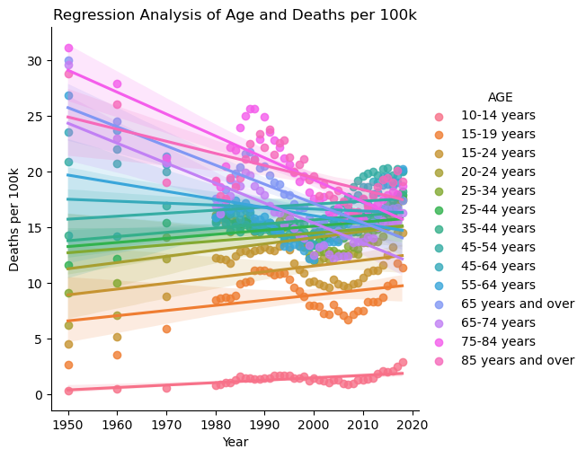

```python
#Actual regression
formula = 'DEATH_PER_100k ~ AGE'
model = smf.ols(formula=formula, data=df).fit()
print(model.summary())

#Regression by year graph
ols_analysis = smf.ols(formula="DEATH_PER_100k ~ YEAR ", data=age_grouped_df).fit()

sns.lmplot(x='YEAR', y='DEATH_PER_100k', hue='AGE', data=age_grouped_df)

# Add labels and title
plt.xlabel('Year')
plt.ylabel('Deaths per 100k')
plt.title('Regression Analysis of Age and Deaths per 100k')

# Show the plot
plt.show()
```

### Hypothesis Testing and Model Analysis of Race

```
                            OLS Regression Results
==============================================================================
Dep. Variable:         DEATH_PER_100k   R-squared:                       0.142
Model:                            OLS   Adj. R-squared:                  0.141
Method:                 Least Squares   F-statistic:                     226.7
Date:                Sat, 18 May 2024   Prob (F-statistic):          2.25e-180
Time:                        23:03:55   Log-Likelihood:                -20770.
No. Observations:                5484   AIC:                         4.155e+04
Df Residuals:                    5479   BIC:                         4.158e+04
Df Model:                           4
Covariance Type:            nonrobust
======================================================================================
                         coef    std err          t      P>|t|      [0.025      0.975]
--------------------------------------------------------------------------------------
Intercept              7.5579      0.422     17.907      0.000       6.730       8.385
RACE[T.all]            6.2496      0.474     13.175      0.000       5.320       7.180
RACE[T.black]          0.2020      0.561      0.360      0.719      -0.897       1.301
RACE[T.indigenous]    10.3449      0.636     16.262      0.000       9.098      11.592
RACE[T.white]         12.3343      0.534     23.091      0.000      11.287      13.382
==============================================================================
Omnibus:                     1453.791   Durbin-Watson:                   0.073
Prob(Omnibus):                  0.000   Jarque-Bera (JB):             4310.566
Skew:                           1.370   Prob(JB):                         0.00
Kurtosis:                       6.370   Cond. No.                         7.89
==============================================================================

Notes:
[1] Standard Errors assume that the covariance matrix of the errors is correctly specified.
```

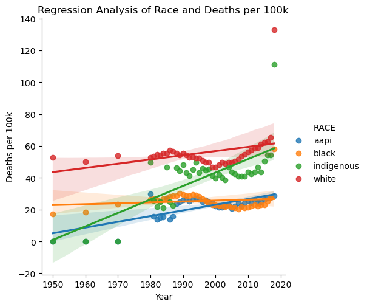

```python
formula = 'DEATH_PER_100k ~ RACE'
model = smf.ols(formula=formula, data=df).fit()
print(model.summary())

ols_analysis = smf.ols(formula="DEATH_PER_100k ~ YEAR ", data=race_grouped_df).fit()

# Scatter plot with regression line
sns.lmplot(x='YEAR', y='DEATH_PER_100k', hue='RACE', data=race_grouped_df)

# Add labels and title
plt.xlabel('Year')
plt.ylabel('Deaths per 100k')
plt.title('Regression Analysis of Race and Deaths per 100k')

# Show the plot
plt.show()
```

In this graph, we see a generally positive slope in the rate of suicide for all populations, with a significant increase in suicide rate from indigenous populations. Looking at our OLS regression results, using a significance value of 0.05, we can say that most of these lines are statistically strong predictors of suicide rates for all categories with the exception of black populations.

### Hypothesis Testing and Model Analysis of Gender

**(H_0)**: No relationship exists between gender and suicide rate.

```
                            OLS Regression Results
==============================================================================
Dep. Variable:         DEATH_PER_100k   R-squared:                       0.437
Model:                            OLS   Adj. R-squared:                  0.437
Method:                 Least Squares   F-statistic:                     2128.
Date:                Sat, 18 May 2024   Prob (F-statistic):               0.00
Time:                        23:02:30   Log-Likelihood:                -19614.
No. Observations:                5484   AIC:                         3.923e+04
Df Residuals:                    5481   BIC:                         3.925e+04
Df Model:                           2
Covariance Type:            nonrobust
====================================================================================
                       coef    std err          t      P>|t|      [0.025      0.975]
------------------------------------------------------------------------------------
Intercept           14.2472      0.334     42.682      0.000      13.593      14.902
GENDER[T.female]    -9.2978      0.380    -24.441      0.000     -10.044      -8.552
GENDER[T.male]       7.0089      0.375     18.690      0.000       6.274       7.744
==============================================================================
Omnibus:                     2085.086   Durbin-Watson:                   0.106
Prob(Omnibus):                  0.000   Jarque-Bera (JB):            11850.745
Skew:                           1.724   Prob(JB):                         0.00
Kurtosis:                       9.323   Cond. No.                         6.05
==============================================================================

Notes:
[1] Standard Errors assume that the covariance matrix of the errors is correctly specified.
```

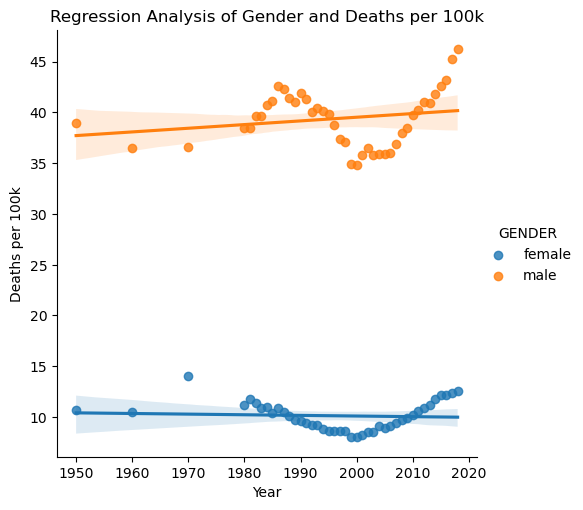

```python
formula = 'DEATH_PER_100k ~ GENDER'
model = smf.ols(formula=formula, data=df).fit()
print(model.summary())

ols_analysis = smf.ols(formula="DEATH_PER_100k ~ YEAR ", data=gender_grouped_df).fit()
# Scatter plot with regression line
sns.lmplot(x='YEAR', y='DEATH_PER_100k', hue='GENDER', data=gender_grouped_df)

# Add labels and title
plt.xlabel('Year')
plt.ylabel('Deaths per 100k')
plt.title('Regression Analysis of Gender and Deaths per 100k')

# Show the plot
plt.show()
```

### Hypothesis Testing and Model Analysis of Ethnicity

**(H_0)**: No relationship exists between ethinicity and suicide rate.

```
                            OLS Regression Results
==============================================================================
Dep. Variable:         DEATH_PER_100k   R-squared:                       0.021
Model:                            OLS   Adj. R-squared:                  0.021
Method:                 Least Squares   F-statistic:                     59.71
Date:                Sat, 18 May 2024   Prob (F-statistic):           2.22e-26
Time:                        23:02:56   Log-Likelihood:                -21131.
No. Observations:                5484   AIC:                         4.227e+04
Df Residuals:                    5481   BIC:                         4.229e+04
Df Model:                           2
Covariance Type:            nonrobust
==========================================================================================
                             coef    std err          t      P>|t|      [0.025      0.975]
------------------------------------------------------------------------------------------
Intercept                 13.5365      0.341     39.685      0.000      12.868      14.205
IS_HISPANIC[T.unknown]     0.8214      0.386      2.126      0.034       0.064       1.579
IS_HISPANIC[T.yes]        -5.6677      0.661     -8.573      0.000      -6.964      -4.372
==============================================================================
Omnibus:                     1705.910   Durbin-Watson:                   0.074
Prob(Omnibus):                  0.000   Jarque-Bera (JB):             5078.134
Skew:                           1.621   Prob(JB):                         0.00
Kurtosis:                       6.423   Cond. No.                         5.99
==============================================================================

Notes:
[1] Standard Errors assume that the covariance matrix of the errors is correctly specified.
```

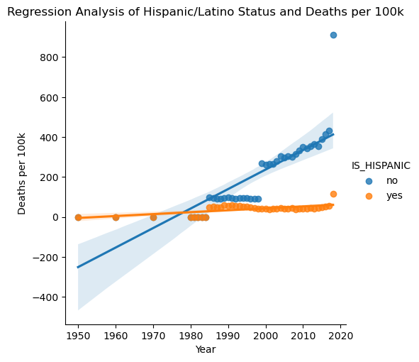

```python
formula = 'DEATH_PER_100k ~ IS_HISPANIC'
model = smf.ols(formula=formula, data=df).fit()
print(model.summary())

ols_analysis = smf.ols(formula="DEATH_PER_100k ~ YEAR ", data=hisp_grouped_df).fit()
# Scatter plot with regression line
sns.lmplot(x='YEAR', y='DEATH_PER_100k', hue='IS_HISPANIC', data=hisp_grouped_df)

# Add labels and title
plt.xlabel('Year')
plt.ylabel('Deaths per 100k')
plt.title('Regression Analysis of Hispanic/Latino Status and Deaths per 100k')

# Show the plot
plt.show()
```

### Final Hypothesis Testing and Model Analysis Utilizing All Independent Variables

```python
formula = 'DEATH_PER_100k ~ AGE + GENDER + IS_HISPANIC + RACE'
FinalModel = smf.ols(formula=formula, data=df).fit()
print(FinalModel.summary())
```

```
                            OLS Regression Results
==============================================================================
Dep. Variable:         DEATH_PER_100k   R-squared:                       0.741
Model:                            OLS   Adj. R-squared:                  0.740
Method:                 Least Squares   F-statistic:                     709.1
Date:                Sat, 18 May 2024   Prob (F-statistic):               0.00
Time:                        22:14:39   Log-Likelihood:                -17489.
No. Observations:                5484   AIC:                         3.502e+04
Df Residuals:                    5461   BIC:                         3.518e+04
Df Model:                          22
Covariance Type:            nonrobust
============================================================================================
                               coef    std err          t      P>|t|      [0.025      0.975]
--------------------------------------------------------------------------------------------
Intercept                   -5.3743      0.687     -7.820      0.000      -6.722      -4.027
AGE[T.15-19 years]           7.3467      0.744      9.871      0.000       5.888       8.806
AGE[T.15-24 years]          11.9660      0.601     19.906      0.000      10.788      13.144
AGE[T.20-24 years]          12.4563      0.744     16.736      0.000      10.997      13.915
AGE[T.25-34 years]          13.0221      0.744     17.496      0.000      11.563      14.481
AGE[T.25-44 years]          13.5725      0.600     22.612      0.000      12.396      14.749
AGE[T.35-44 years]          14.2642      0.744     19.165      0.000      12.805      15.723
AGE[T.45-54 years]          15.7737      0.744     21.193      0.000      14.315      17.233
AGE[T.45-64 years]          12.6736      0.602     21.058      0.000      11.494      13.853
AGE[T.55-64 years]          15.2769      0.744     20.525      0.000      13.818      16.736
AGE[T.65 years and over]    15.1564      0.607     24.956      0.000      13.966      16.347
AGE[T.65-74 years]          14.7655      0.673     21.950      0.000      13.447      16.084
AGE[T.75-84 years]          21.8215      0.674     32.371      0.000      20.500      23.143
AGE[T.85 years and over]    30.2459      0.699     43.255      0.000      28.875      31.617
AGE[T.All ages]             10.1531      0.579     17.536      0.000       9.018      11.288
GENDER[T.female]            -6.6763      0.291    -22.966      0.000      -7.246      -6.106
GENDER[T.male]               8.8363      0.290     30.428      0.000       8.267       9.406
IS_HISPANIC[T.unknown]      -0.7480      0.223     -3.359      0.001      -1.185      -0.311
IS_HISPANIC[T.yes]          -6.9883      0.418    -16.703      0.000      -7.808      -6.168
RACE[T.all]                  6.7040      0.325     20.632      0.000       6.067       7.341
RACE[T.black]               -1.1446      0.311     -3.685      0.000      -1.754      -0.536
RACE[T.indigenous]          10.1138      0.353     28.639      0.000       9.421      10.806
RACE[T.white]               10.2099      0.296     34.454      0.000       9.629      10.791
==============================================================================
Omnibus:                     1149.321   Durbin-Watson:                   0.176
Prob(Omnibus):                  0.000   Jarque-Bera (JB):             5870.674
Skew:                           0.914   Prob(JB):                         0.00
Kurtosis:                       7.728   Cond. No.                         40.9
==============================================================================

Notes:
[1] Standard Errors assume that the covariance matrix of the errors is correctly specified.
```

While the model above may be difficult to parse, we will break it down here. First we begin with our intercept the coefficient is -5.3743 which means which means that when all other variables (Age, Race, Gender, and Ethnicity) are held constant at zero. This represents the baseline level of the dependent variable when all predictors are absent or at their reference level. Depending on if one means the criteria (eg. AGE[T.15-19 years], between 15 and 19 years of age), the probability of suicide increases or decreases depending on the coeffiecient value (in this case an increase of 7.3467. The dependent values all have a p-value of less than .05 and are thus statistcally significant. This means the null hypothesis of no relationship is rejected and these predictors have a significant impact on the probability of suicide.

## Machine Leaning

### ML on Age

```python
# Filter out rows where AGE_NUM is 0
filtered_df = df[(df['AGE'] != 'All ages') &
                 (df['AGE'] != '65 years and over') &
                 (df['RACE'] != 'all') &
                 (df['GENDER'] != 'both')]
filtered_df = filtered_df.dropna()

# Prepare the feature matrix (X) and the target vector (y)
X = filtered_df[['YEAR', 'DEATH_PER_100k']]
y = filtered_df['AGE']

# Split the data into training and testing sets
X_train, X_test, y_train, y_test = train_test_split(X, y, test_size=0.2, random_state=42)

# Initialize the KNN classifier
knn = KNeighborsClassifier(n_neighbors=3)

# Fit the classifier to the training data
knn.fit(X_train, y_train)

# Make predictions on the testing set
y_pred = knn.predict(X_test)

# Evaluate the classifier
print("Confusion Matrix:")
print(confusion_matrix(y_test, y_pred))
print("\nClassification Report:")
print(classification_report(y_test, y_pred))

# Example of making a prediction
ex_year, ex_death = 2010, 5
example_data = pd.DataFrame({'YEAR': [2010], 'DEATH_PER_100k': [5]})
example_prediction = knn.predict(example_data)
print(f"\nPrediction for YEAR={ex_year}, DEATH_PER_100k={ex_death}: {example_prediction[0]}")
```

```
Confusion Matrix:
[[45 27 17  0  1  1]
 [31 39 25  4  0  0]
 [41 23 25  0  1  0]
 [ 3  5  6  4  0  0]
 [ 6  2  3  3  5  2]
 [ 3  0  0  0  0  7]]

Classification Report:
                   precision    recall  f1-score   support

      15-24 years       0.35      0.49      0.41        91
      25-44 years       0.41      0.39      0.40        99
      45-64 years       0.33      0.28      0.30        90
      65-74 years       0.36      0.22      0.28        18
      75-84 years       0.71      0.24      0.36        21
85 years and over       0.70      0.70      0.70        10

         accuracy                           0.38       329
        macro avg       0.48      0.39      0.41       329
     weighted avg       0.40      0.38      0.38       329


Prediction for YEAR=2010, DEATH_PER_100k=5: 45-64 years
```

### ML on Race

```python
# Filter out rows where AGE_NUM is 0
filtered_df = df[(df['AGE'] != 'All ages') &
                 (df['AGE'] != '65 years and over') &
                 (df['RACE'] != 'all') &
                 (df['GENDER'] != 'both')]
filtered_df = filtered_df.dropna()

# Prepare the feature matrix (X) and the target vector (y)
X = filtered_df[['YEAR', 'DEATH_PER_100k']]
y = filtered_df['RACE']

# Split the data into training and testing sets
X_train, X_test, y_train, y_test = train_test_split(X, y, test_size=0.2, random_state=42)

# Initialize the KNN classifier
knn = KNeighborsClassifier(n_neighbors=3)

# Fit the classifier to the training data
knn.fit(X_train, y_train)

# Make predictions on the testing set
y_pred = knn.predict(X_test)

# Evaluate the classifier
print("Confusion Matrix:")
print(confusion_matrix(y_test, y_pred))
print("\nClassification Report:")
print(classification_report(y_test, y_pred))

# Example of making a prediction
ex_year, ex_death = 2010, 5
example_data = pd.DataFrame({'YEAR': [2010], 'DEATH_PER_100k': [5]})
example_prediction = knn.predict(example_data)
print(f"\nPrediction for YEAR={ex_year}, DEATH_PER_100k={ex_death}: {example_prediction[0]}")
```

```
Confusion Matrix:
[[41 11  3 13]
 [24 58  5  9]
 [ 6 15 12 23]
 [11  5 14 79]]

Classification Report:
              precision    recall  f1-score   support

        aapi       0.50      0.60      0.55        68
       black       0.65      0.60      0.63        96
  indigenous       0.35      0.21      0.27        56
       white       0.64      0.72      0.68       109

    accuracy                           0.58       329
   macro avg       0.54      0.54      0.53       329
weighted avg       0.56      0.58      0.57       329


Prediction for YEAR=2010, DEATH_PER_100k=5: aapi
```

### ML on Gender

```python
# Filter out rows where AGE_NUM is 0
filtered_df = df[(df['AGE'] != 'All ages') &
                 (df['AGE'] != '65 years and over') &
                 (df['RACE'] != 'all') &
                 (df['GENDER'] != 'both')]
filtered_df = filtered_df.dropna()

# Prepare the feature matrix (X) and the target vector (y)
X = filtered_df[['YEAR', 'DEATH_PER_100k']]
y = filtered_df['GENDER']

# Split the data into training and testing sets
X_train, X_test, y_train, y_test = train_test_split(X, y, test_size=0.2, random_state=42)

# Initialize the KNN classifier
knn = KNeighborsClassifier(n_neighbors=3)

# Fit the classifier to the training data
knn.fit(X_train, y_train)

# Make predictions on the testing set
y_pred = knn.predict(X_test)

# Evaluate the classifier
print("Confusion Matrix:")
print(confusion_matrix(y_test, y_pred))
print("\nClassification Report:")
print(classification_report(y_test, y_pred))

# Example of making a prediction
ex_year, ex_death = 2010, 5
example_data = pd.DataFrame({'YEAR': [2010], 'DEATH_PER_100k': [5]})
example_prediction = knn.predict(example_data)
print(f"\nPrediction for YEAR={ex_year}, DEATH_PER_100k={ex_death}: {example_prediction[0]}")
```

```
Confusion Matrix:
[[ 99  15]
 [ 21 194]]

Classification Report:
              precision    recall  f1-score   support

      female       0.82      0.87      0.85       114
        male       0.93      0.90      0.92       215

    accuracy                           0.89       329
   macro avg       0.88      0.89      0.88       329
weighted avg       0.89      0.89      0.89       329


Prediction for YEAR=2010, DEATH_PER_100k=5: female
```

## Part 5: Interpolation: Insight and Policy Decision

**Insight:**  
The goal of this project has been achieved. Through meticulous analysis, statistic models, and careful examination of the data we found that group most vulnerable to suicide is older white, non-hispanic, males. This is consistent with numerous sources we researched in tandem with this project. Now that we are able to identify the demographic most vulnerable to suicide, we may take measures to address this crisis.

**Solutions:**  
As provided within the disclaimer portion of this project (at the top of the page you will find the disclaimer), these are all resources that help with suicidal ideation and preventative measures. But this is not enough. According to the American Foundation for Suicide Prevention 94% of Americans believe that suicide can be prevented, this is the position of this project. Here are some solutions we present to the issue:

```
1. Foster socio-emotional life skills in adolescents.<sup>13</sup> <br>
2. Regularly access and check in populations at higher risk of committing suicide. <br>
3. Promotion of metal health awareness for vulnerbale populations. <br>
4. Strengthen support networks. <br>
5. Increase access to services. <br>
```

## Works Cited

(This work cited was completed in MLA 9 format and all links direct you to sources.)

**Introduction**

1. “Suicide Statistics.” American Foundation for Suicide Prevention, 15 May 2024, afsp.org/suicide-statistics/#:~:text=Additional%20facts%20about%20suicide%20in,54.64%25%20of%20all%20suicide%20deaths.
2. Wang, Xiaochuan et al. “Suicide Risk Help-Seeking Among Middle- to Old-Age Adults: A Systematic Review.” Innovation in aging vol. 7,1 igac079. 25 Jan. 2023, https://www.ncbi.nlm.nih.gov/pmc/articles/PMC9940623/
3. VIGDERHOUS, GIDEON, and GIDEON FISHMAN. “SOCIOECONOMIC DETERMINANTS OF FEMALE SUICIDE RATES: A CROSS-NATIONAL COMPARISON.” International Review of Modern Sociology, vol. 7, no. 2, 1977, pp. 199–211. JSTOR, [http://www.jstor.org/stable/23565734](https://www.jstor.org/stable/23565734).

**Data Collection**

1. List of sources on data science, Python, and Jupiter:

   ```
             a. Skills the next generation of data scientists need to know: [https://hbr.org/2023/09/4-skills-the-next-generation-of-data-scientists-needs-to-develop](https://hbr.org/2023/09/4-skills-the-next-generation-of-data-scientists-needs-to-develop)<br>
             b. What is Python?: [https://www.python.org/doc/essays/blurb/](https://www.python.org/doc/essays/blurb/)<br>
             c. Python Documentation [https://hbr.org/2023/09/4-skills-the-next-generation-of-data-scientists-needs-to-develop] (https://hbr.org/2023/09/4-skills-the-next-generation-of-data-scientists-needs-to-develop)<br>
             d. Jupiter Notebook: [https://jupyter.org/](https://jupyter.org/) <br>
   ```

2. “U.S. Department of Health & Human Services - Death Rates for Suicide, by Sex, Race, Hispanic Origin, and Age: United States.” Catalog, Publisher Centers for Disease Control and Prevention, 28 Apr. 2022, catalog.data.gov/dataset/death-rates-for-suicide-by-sex-race-hispanic-origin-and-age-united-states-020c1.
3. Bureau, US Census. “United States Census.” Census.Gov, 12 May 2024, [www.census.gov](https://www.census.gov/).
4. “Working with Missing Data.” Working with Missing Data - Pandas 2.2.2 Documentation, pandas.pydata.org/docs/user_guide/missing_data.html.

**Exploratory Analysis and Data Visualization:**

1. Zilkha, Chloe. “Suicide Rates Are High and Rising among Older Adults In ...” Health Affairs, [www.healthaffairs.org/do/10.1377/forefront.20240228.27143/](https://www.healthaffairs.org/content/forefront/suicide-rates-high-and-rising-among-older-adults-us#:~:text=In%20November%202023%2C%20the%20Centers,groups%2C%20largely%20driven%20by%20males.).
2. Morris, J.B, et al. “Why Women Are Less Likely than Men to Commit Suicide.” Comprehensive Psychiatry, W.B. Saunders, 28 June 2004, https://www.sciencedirect.com/science/article/pii/S0010440X98900578?via%3Dihub.
3. “White Populations.” White Populations – Suicide Prevention Resource Center, https://sprc.org/about-suicide/scope-of-the-problem/racial-and-ethnic-disparities/white-populations/.
4. Frakt, Austin. “What Can Be Learned from Differing Rates of Suicide among Groups.” The New York Times, The New York Times, 30 Dec. 2020, https://www.nytimes.com/2020/12/30/upshot/suicide-demographic-differences.html.

**Hypothesis Testing, Model Analysis, and Machine Learning:**

1. “Hypothesis Testing: The Basics.” 20bits by Jesse Farmer, 20bits.com/article/hypothesis-testing-the-basics.

**Interpolation: Insight and Policy Decision:**

1. “Suicide.” World Health Organization, World Health Organization, https://www.who.int/health-topics/suicide#tab=tab_2.